# Chapter 6

Jukke Kaaronen

27/11/2020

# Chapter 6 Analysis of Longitudinal Data

## 1.1 Library

```r
library(tidyverse)
library(knitr)
```

## 1.2 Load datasets

```r
setwd("C:/Users/Jukke/OneDrive/Työpöytä/IODS/IODS-project/data")
long_BPRS <- read.table("long_BPRS.txt", sep = ",", header = TRUE)
long_RATS <- read.table("long_RATS.txt", sep = ",", header = TRUE)
str(long_BPRS)
```

```
## 'data.frame':    360 obs. of  5 variables:
##  $ treatment : int  1 1 1 1 1 1 1 1 1 1 ...
##  $ subject   : int  1 2 3 4 5 6 7 8 9 10 ...
##  $ weeks     : chr  "week0" "week0" "week0" "week0" ...
##  $ bprs_score: int  42 58 54 55 72 48 71 30 41 57 ...
##  $ week      : int  0 0 0 0 0 0 0 0 0 0 ...
```

```r
str(long_RATS)
```

```
## 'data.frame':    176 obs. of  5 variables:
##  $ ID    : int  1 2 3 4 5 6 7 8 9 10 ...
##  $ Group : int  1 1 1 1 1 1 1 1 2 2 ...
##  $ WD    : chr  "WD1" "WD1" "WD1" "WD1" ...
##  $ Weight: int  240 225 245 260 255 260 275 245 410 405 ...
##  $ Time  : int  1 1 1 1 1 1 1 1 1 1 ...
```

## 1.3 Minor (Re-)Wrangles

Need to change category variables to factors as they aren’t read properly:

```r
long_RATS$ID <- as.factor(long_RATS$ID)
long_RATS$Group <- as.factor(long_RATS$Group)
long_BPRS$treatment <- as.factor(long_BPRS$treatment)
long_BPRS$subject <- as.factor(long_BPRS$subject)
str(long_BPRS)
```

```
## 'data.frame':    360 obs. of  5 variables:
##  $ treatment : Factor w/ 2 levels "1","2": 1 1 1 1 1 1 1 1 1 1 ...
##  $ subject   : Factor w/ 20 levels "1","2","3","4",..: 1 2 3 4 5 6 7 8 9 10 ...
##  $ weeks     : chr  "week0" "week0" "week0" "week0" ...
##  $ bprs_score: int  42 58 54 55 72 48 71 30 41 57 ...
##  $ week      : int  0 0 0 0 0 0 0 0 0 0 ...
```

```r
str(long_RATS)
```

```
## 'data.frame':    176 obs. of  5 variables:
##  $ ID    : Factor w/ 16 levels "1","2","3","4",..: 1 2 3 4 5 6 7 8 9 10 ...
##  $ Group : Factor w/ 3 levels "1","2","3": 1 1 1 1 1 1 1 1 2 2 ...
##  $ WD    : chr  "WD1" "WD1" "WD1" "WD1" ...
##  $ Weight: int  240 225 245 260 255 260 275 245 410 405 ...
##  $ Time  : int  1 1 1 1 1 1 1 1 1 1 ...
```

Great.

## 2 RATS!

## 2.1 Rat Dataset

The aim of the first part of this exercise here is to follow the steps in chapter 8 of Vehkalahti & Everitt (2019) and perform a summary measure method of analysis on a dataset about rats. In this method, the values of multiple observations are changed into a single value. This can be used as an exploratory method to look at the data.  
The rats dataset contains 176 observations of rat weights (in grams) that are complemented with information of rat subject (16 rat subjects) and its test group (rats assigned in 3 groups) over a time of 64 days. Below, a table of the first, 10th, 20th, .. and 50th observation of the `long_RATS` dataset, printed with `kable()` from the `knitr` package.

```r
kable(long_RATS[c(1,10,20,30,40,50),], caption = "Rats, so many rats!", row.names = FALSE, align = "ccccc")
```

Rats, so many rats!

| ID | Group | WD | Weight | Time |
| --- | --- | --- | --- | --- |
| 1 | 1 | WD1 | 240 | 1 |
| 10 | 2 | WD1 | 405 | 1 |
| 4 | 1 | WD8 | 255 | 8 |
| 14 | 3 | WD8 | 525 | 8 |
| 8 | 1 | WD15 | 260 | 15 |
| 2 | 1 | WD22 | 232 | 22 |

For some good luck, let’s look at the observations of Rat No. 13:

```r
kable(long_RATS[long_RATS$ID == "13",], row.names = FALSE, align = "ccccc")
```

| ID | Group | WD | Weight | Time |
| --- | --- | --- | --- | --- |
| 13 | 3 | WD1 | 470 | 1 |
| 13 | 3 | WD8 | 465 | 8 |
| 13 | 3 | WD15 | 475 | 15 |
| 13 | 3 | WD22 | 485 | 22 |
| 13 | 3 | WD29 | 487 | 29 |
| 13 | 3 | WD36 | 493 | 36 |
| 13 | 3 | WD43 | 493 | 43 |
| 13 | 3 | WD44 | 504 | 44 |
| 13 | 3 | WD50 | 507 | 50 |
| 13 | 3 | WD57 | 518 | 57 |
| 13 | 3 | WD64 | 525 | 64 |

So Rat No. 13 belongs to the Group 3 and we have 11 observations of its weight development, which increases from 470 to 525 over the course of the time period. So unless they are hitting the gym, there appears to be some rat growth going on in this dataset. Who else belongs to Group 3? Let’s have a look at the number of rats in each group.

```r
rat_per_group <- long_RATS %>% filter(Time == 1) %>% group_by(Group) %>% count() %>% rename("Rats in Group" = n) %>% ungroup()
kable(rat_per_group, caption = "Rats Numbers in 3 Groups", row.names = FALSE, align = "cc")
```

Rats Numbers in 3 Groups

| Group | Rats in Group |
| --- | --- |
| 1 | 8 |
| 2 | 4 |
| 3 | 4 |

Group 1 has eight rats while Groups 2 and 3 have four rats each.

## 2.2 Plotting the Rat Fattening

First, lets plot our rodents gain trails with a `geom_line()` plot of their growth over the 64 day time period. Here the plots are faceted by the three groups discussed above, and we can see how the rats gain weight (and sometimes also lose weight) between the measurements. In this plot I use the argument `linetype =` to specify we want the line types following the Rat ID. In `scale_x_continuous()` I define the argument `breaks =` to contain the measurement days of the dataset and give them names accordingly in the `labels =` argument.  
In general, all the rats seem to gain weight during the time period. Weight gain seems to be slightly larger in groups 2 and 3. Note that there were two consecutive measurements on day 43 and 44, after which most rats in group 2 and 3 exhibit an increase in weight, suggesting, perhaps, a cheese dinner.

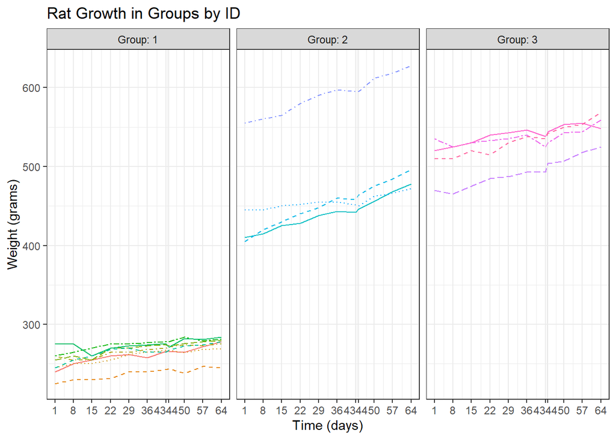

```r
ggplot(long_RATS, aes(x = Time, y = Weight, linetype = ID)) +
  geom_line(aes(col = ID)) + scale_linetype_manual(values = rep(1:8, times=2)) +
  facet_grid(. ~ Group, labeller = label_both) +
  scale_y_continuous(limits = c(min(long_RATS$Weight), max(long_RATS$Weight))) +
  scale_x_continuous(breaks = c(1,8,15,22,29,36,43,44,50,57,64), labels = c("1", "8", "15", "22", "29", "36", "4344", "", "50", "57", "64")) +
  theme_bw() + labs(y = "Weight (grams)", x = "Time (days)") + theme(legend.position = "none", axis.text.x = element_text(angle = 0)) + ggtitle("Rat Growth in Groups by ID")
```

Each group also has a bit of an outlier. The outlier in Group 2 is a particularly big rat. Let’s see if we can find this beast, which should be easy as from the plot we see it is the only rat that exceeds the respectable size of 600 grams.

```r
fat_rat <- long_RATS %>% filter(Weight > 600) %>% dplyr::select(ID)
fat_rat[2,]
```

```
## [1] 12
## Levels: 1 2 3 4 5 6 7 8 9 10 11 12 13 14 15 16
```

So it’s Rat No. 12. I have a hunch this plague bringer may cause some trouble up ahead. But first, let’s standardize the `long_RATS` dataset to see if something changes.

### 2.2.1 Standardizing the Rat Growth

As we have learned, to standardize a dataset we need to substract the relevant occasion (i.e. measuring day) column mean divided by column standard deviation from the column. This can be done with either the `mean()` and `sd()` functions or use the `scale()` function which gives the same results after the data is `group_by()` the relevant occasion. Thus, rat weights are standardized by day of measurement (the Time variable).

```r
long_RATS_w_std <- long_RATS %>%
  group_by(Time) %>%
  mutate(Weight_std = scale(Weight)) %>%
  ungroup()
```

Now we have a dataset (`long_RATS_w_std`) of rats with STD’s with standardized weights in a new column. So let’s plot it with the same code as above. In general, the rats maintain their relevant position with regards to each other. Group 1 is significantly lighter, remaining in the (-1 area), Group 2 maintains it’s position (with Rat No. 12 as the outlier) and Group 3 has the highest distance from the mean at over 1:

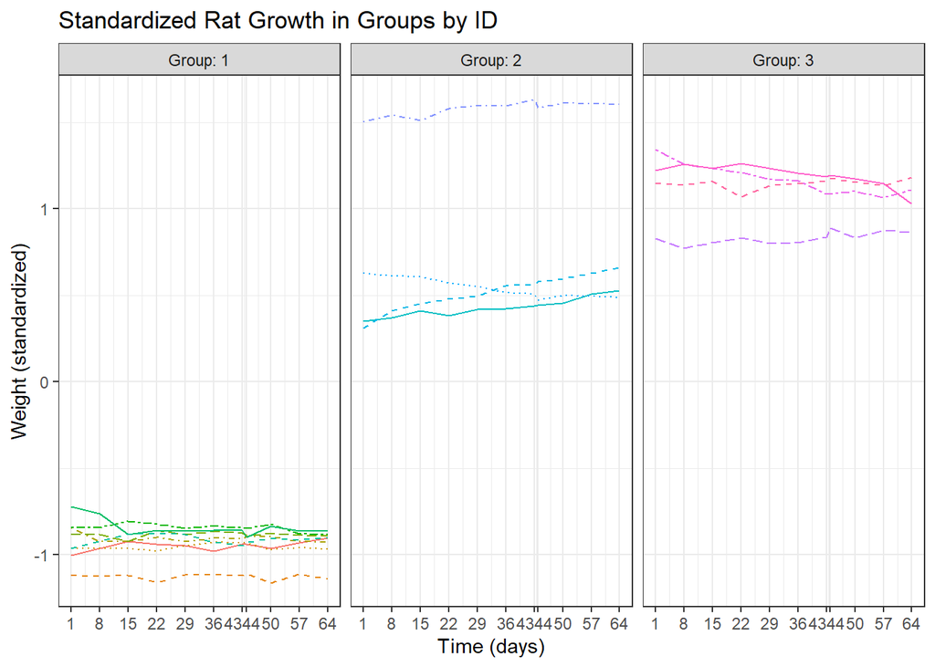

```r
ggplot(long_RATS_w_std, aes(x = Time, y = Weight_std, linetype = ID)) +
  geom_line(aes(col = ID)) + scale_linetype_manual(values = rep(1:8, times=2)) +
  facet_grid(. ~ Group, labeller = label_both) +
  scale_y_continuous(limits = c(min(long_RATS_w_std$Weight_std), max(long_RATS_w_std$Weight_std))) +
  scale_x_continuous(breaks = c(1,8,15,22,29,36,43,44,50,57,64), labels = c("1", "8", "15", "22", "29", "36", "4344", "", "50", "57", "64")) +
  theme_bw() + labs(y = "Weight (standardized)", x = "Time (days)") + theme(legend.position = "none", axis.text.x = element_text(angle = 0)) + ggtitle("Standardized Rat Growth in Groups by ID")
```

### 2.2.2 Mean Profiles

Average profiles for each Rat Pack can also be plotted. For this we need to also count the standard error, which is `sd(x) / sqrt(n, where n is the size (number of observations) of the sample)`. There was some discussion about this on the course forum where a student pointed out that the standard error used in the DataCamp example was, in fact, not correct. So I put together two alternatives, done below. The datacamp code uses n as the amount of observation times, but apparently it is slightly more clever to use n as the number of observations in a group per time. So we would want n to be 8 for group 1 and 4 for groups 2 and 3.

```r
# The DataCamp way:
n <- long_RATS$Time %>% unique() %>% length()

l_RATS_summarya <- long_RATS %>%
  group_by(Group, Time) %>%
  summarise( mean = mean(Weight), se = sd(Weight) / sqrt(n)) %>%
  ungroup()
# The other way:

n1 <- long_RATS %>% filter(Group == "1") %>% group_by(Group, Time) %>% count(Group) %>% ungroup() %>% dplyr::select(n) %>% distinct() %>% as.integer()
n2 <- long_RATS %>% filter(Group == "2") %>% group_by(Group, Time) %>% count(Group) %>% ungroup() %>% dplyr::select(n) %>% distinct() %>% as.integer()
n3 <- long_RATS %>% filter(Group == "3") %>% group_by(Group, Time) %>% count(Group) %>% ungroup() %>% dplyr::select(n) %>% distinct() %>% as.integer()

l_RATS_summaryb <- long_RATS %>%
  group_by(Group, Time) %>%
  summarise( mean = mean(Weight), se = sd(Weight) / sqrt(case_when(Group == "1" ~ n1,
                                                                   Group == "2" ~ n2,
                                                                   Group == "3" ~ n3))) %>% distinct() %>% ungroup()
# This is extra code saving for later
#n4 <- as.integer(distinct(select(ungroup(count(group_by(filter(long_RATS, Group == 1), Group, Time))),n)))
#
#l_RATS_summaryc <- long_RATS %>%
#  group_by(Group, Time) %>%
#  summarise( mean = mean(Weight), se = sd(Weight) / sqrt(case_when(Group == "1" ~ #as.integer(distinct(select(ungroup(count(group_by(filter(long_RATS, Group == "1"), Group, Time))),n))),
#                                                                   Group == "2" ~ #as.integer(distinct(select(ungroup(count(group_by(filter(long_RATS, Group == "2"), Group, Time))),n))),
#                                                                   Group == "3" ~ #as.integer(distinct(select(ungroup(count(group_by(filter(long_RATS, Group == "3"), Group, Time))),n)))))) #%>% distinct() %>% ungroup()
# /extra code
```

**The DataCamp way:**

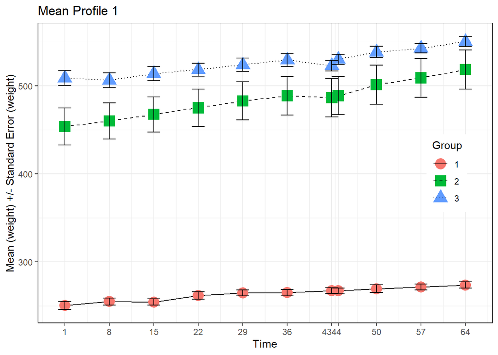

```r
ggplot(l_RATS_summarya, aes(x = Time, y = mean, linetype = Group, shape = Group)) +
  geom_line() +
  scale_linetype_manual(values = c(1,2,3)) +
  geom_point(aes(col = Group), size=5) +
  scale_shape_manual(values = c("circle","square","triangle")) +
  geom_errorbar(aes(ymin=mean-se, ymax=mean+se, linetype="1"), width=2) +
  scale_y_continuous(name = "Mean (weight) +/- Standard Error (weight)") +
  scale_x_continuous(breaks = c(1,8,15,22,29,36,43,44,50,57,64), labels = c("1", "8", "15", "22", "29", "36", "4344", "", "50", "57", "64")) +
  theme_bw() + theme(legend.position = c(0.9,0.5)) + ggtitle("Mean Profile 1")
```

**The Other Way:**

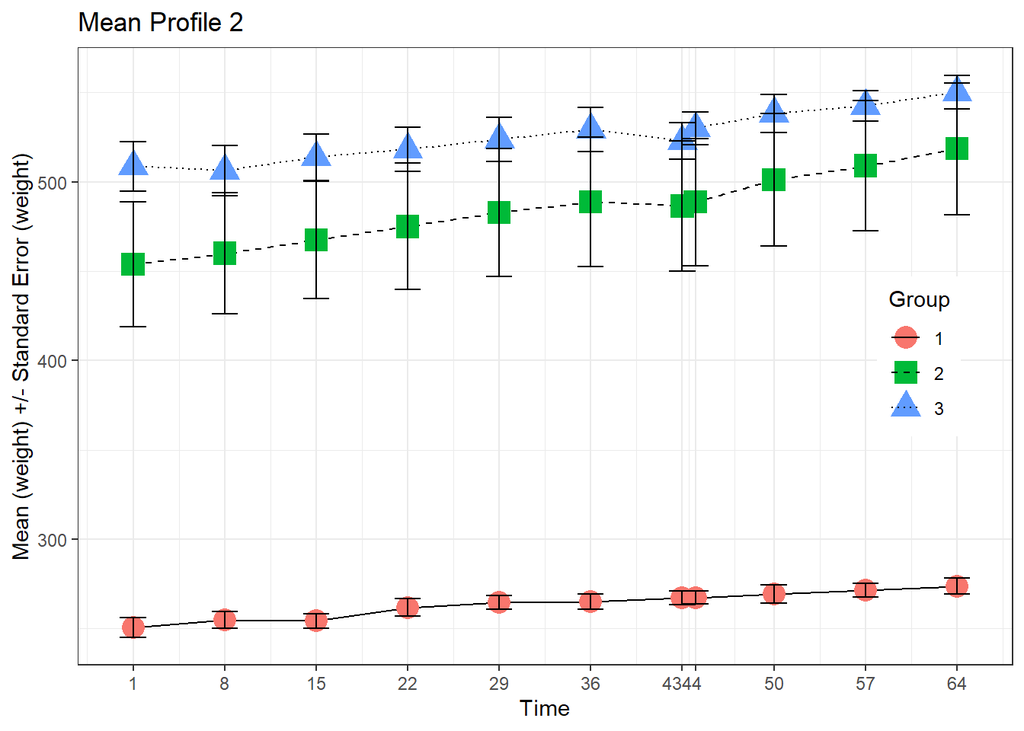

```r
ggplot(l_RATS_summaryb, aes(x = Time, y = mean, linetype = Group, shape = Group)) +
  geom_line() +
  scale_linetype_manual(values = c(1,2,3)) +
  geom_point(aes(col = Group), size=5) +
  scale_shape_manual(values = c("circle","square","triangle")) +
  geom_errorbar(aes(ymin=mean-se, ymax=mean+se, linetype="1"), width=2) +
  scale_y_continuous(name = "Mean (weight) +/- Standard Error (weight)") +
  scale_x_continuous(breaks = c(1,8,15,22,29,36,43,44,50,57,64), labels = c("1", "8", "15", "22", "29", "36", "4344", "", "50", "57", "64")) +
  theme_bw() + theme(legend.position = c(0.9,0.5)) + ggtitle("Mean Profile 2")
```

The main difference is that in “Mean Profile 1” the 3 groups do not overlap at all whereas there is some standard error overlap in “Mean Profile 2”. Standard errors are also larger in “Mean Profile 2”, signified by the line thingies. In both plots Group 2 has the largest standard error, and all groups means exhibit the increase in weight discussed previously. In Group 1 this increase seems to be a bit lower than Groups 2 and 3.

### 2.2.3 Plotting Summarised Mean Weight

To look at the development in rat growth one (not very good) way is to look for the mean weight of the rats over the course of the fattening. We can exclude the first observation from day 1 (we’ll use it as a baseline further on) and then proceed to count the mean for each rat. A boxplot shows the results and possible outliers of the mean summary:

```r
RATS10 <- long_RATS %>%
  filter(Time > 1) %>%
  group_by(Group, ID) %>%
  summarise(mean=mean(Weight)) %>%
  ungroup()
```

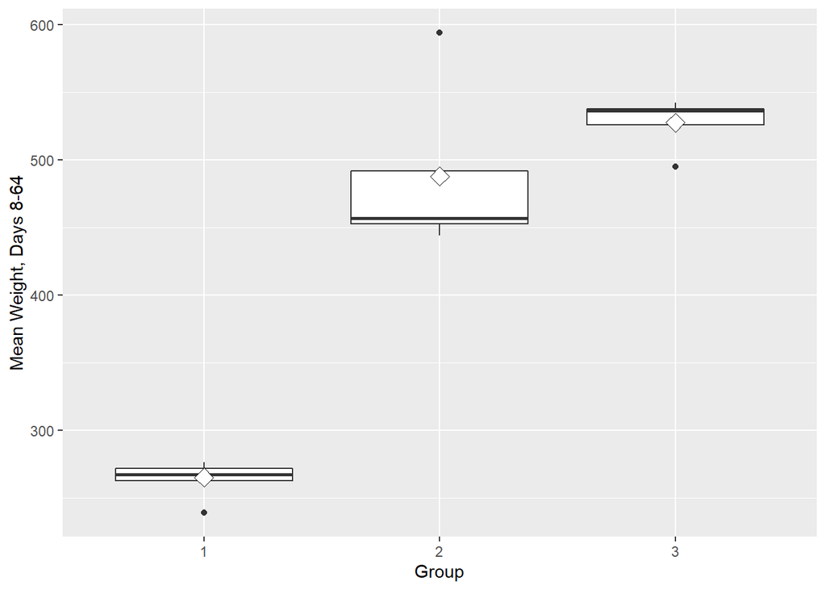

```r
ggplot(RATS10, aes(x = Group, y = mean)) +
  geom_boxplot() +
  stat_summary(fun.y = "mean", geom = "point", shape=23, size=4, fill = "white") +
  scale_y_continuous(name = "Mean Weight, Days 8-64")
```

So not only is Rat No. 12 outliering the cheese out of Group 2, so are the two outliers in Group 1 and Group 3 as well! Group 2 has the most variable mean summary measure, which is also heavily skewed, most likely because of the outlier. Group 1 has the least variable mean summary measure. If we want to get rid of the outliers, we have to find them. We know who the outlier in Group 2 is, and we know the outliers in Groups 1 and 3 are the lightest rats in their respective groups.  
Two ways to do this, first we can simply look at a table and find the correct rat by looking for the ID of the lightest weights in the groups and then filter out those ID’s.  
Or. Say, for some reason, we couldn’t look at the table, I wrote a small code below trying to practice my R. Here, each group is filtered by the first day of measuring and subsequently put in ascending `order()` by weight. Since we want the first (lightest) observation from groups 1 and 3 they can be sussed out with `head(1)` and since we want the last (heaviest) observation from group 2 we can use `tail()` respectively. These assigned values can be bound with `bind_rows` and then `anti_join(ed)` with the summary dataset `RATS10`, which will keep observations not matching ID’s.

```r
wee_rat_finder <- long_RATS %>% filter(Time == 1 & Group != 2)
kable(wee_rat_finder, format = "html", row.names = FALSE, padding = 10, align = "ccccc")
```

| ID | Group | WD | Weight | Time |
| --- | --- | --- | --- | --- |
| 1 | 1 | WD1 | 240 | 1 |
| 2 | 1 | WD1 | 225 | 1 |
| 3 | 1 | WD1 | 245 | 1 |
| 4 | 1 | WD1 | 260 | 1 |
| 5 | 1 | WD1 | 255 | 1 |
| 6 | 1 | WD1 | 260 | 1 |
| 7 | 1 | WD1 | 275 | 1 |
| 8 | 1 | WD1 | 245 | 1 |
| 13 | 3 | WD1 | 470 | 1 |
| 14 | 3 | WD1 | 535 | 1 |
| 15 | 3 | WD1 | 520 | 1 |
| 16 | 3 | WD1 | 510 | 1 |

```r
g1 <- long_RATS %>% filter(Time == 1 & Group == "1")
g1 <- g1[order(g1$Weight),] %>% head(1) %>% dplyr::select(ID)
g2 <- long_RATS %>% filter(Time == 1 & Group == "2")
g2 <- g2[order(g2$Weight),] %>% tail(1) %>% dplyr::select(ID)
g3 <- long_RATS %>% filter(Time == 1 & Group == "3")
g3 <- g3[order(g3$Weight),] %>% head(1) %>% dplyr::select(ID)
remove <- bind_rows(g1,g2,g3)
rats_purged <- anti_join(RATS10,remove)
glimpse(rats_purged)
```

```
## Rows: 13
## Columns: 3
## $ Group <fct> 1, 1, 1, 1, 1, 1, 1, 2, 2, 2, 3, 3, 3
## $ ID    <fct> 1, 3, 4, 5, 6, 7, 8, 9, 10, 11, 14, 15, 16
## $ mean  <dbl> 263.2, 261.7, 267.2, 270.9, 276.2, 274.6, 267.5, 443.9, 457.5...
```

So either way, it’s Rat No. 2 (at a featherweight 225 grams) in Group 1, and Rat No. 13 (at 470 grams) in Group 3. So a quicker option for this case would be to simply remove the outliers by their ID number. Let’s let go of these wee beasts and Rat No. 12. Then perform the same box plot without outliers.

```r
RATS10_purged <- RATS10 %>% filter(ID != 2 & ID != 12 & ID != 13) # Bye you little rascals!
glimpse(RATS10_purged)
```

```
## Rows: 13
## Columns: 3
## $ Group <fct> 1, 1, 1, 1, 1, 1, 1, 2, 2, 2, 3, 3, 3
## $ ID    <fct> 1, 3, 4, 5, 6, 7, 8, 9, 10, 11, 14, 15, 16
## $ mean  <dbl> 263.2, 261.7, 267.2, 270.9, 276.2, 274.6, 267.5, 443.9, 457.5...
```

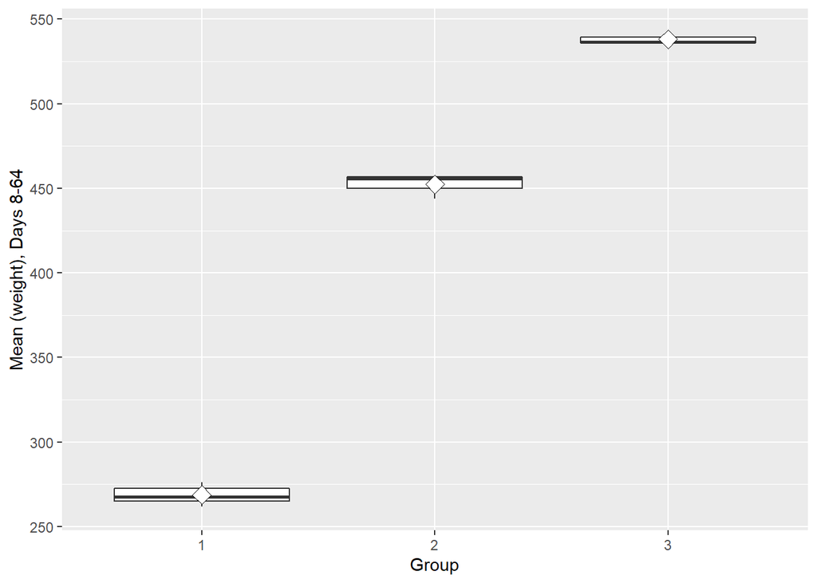

```r
ggplot(RATS10_purged, aes(x = Group, y = mean)) +
  geom_boxplot() +
  stat_summary(fun.y = "mean", geom = "point", shape=23, size=4, fill = "white") +
  scale_y_continuous(name = "Mean (weight), Days 8-64")
```

Well we did what we came to do, now we have seven rats in Group 1, and three rats in Groups 2 and 3 with very little mean summary variation and no outliers. Not sure what to say about this, I sort of miss the 3 rats.. I just feel bad to see anova rat bite the dust.

## 2.3 RAT ANOVA

### 2.3.1 Linear Model

For a three value variable a t-test is apparently not the thing to do (*no, I most certainly did not attempt to do this multiple times, what are you talking about?*), so let’s look at ANOVA. First, we need to create a linear model with `lm()` where the mean is predicted by group. As we saw earlier in the mean profiles plot, where the groups were not overlapping, we might expect to get statistically significant results here as well. There is an option to consider, do we use the dataset with no outliers or the dataset with outliers? The summaries below reveal that the t-values for the dataset with no outliers are much higher, but both summaries arrive at similar conclusions.

```r
lm_RATS <- lm(mean ~ Group, data = RATS10_purged)

lm_RATS2 <- lm(mean ~ Group, data = RATS10)
```

**No outliers:**

```r
summary(lm_RATS)
```

```
##
## Call:
## lm(formula = mean ~ Group, data = RATS10_purged)
##
## Residuals:
##    Min     1Q Median     3Q    Max
## -8.500 -2.067 -1.257  3.933  7.443
##
## Coefficients:
##             Estimate Std. Error t value Pr(>|t|)
## (Intercept)  268.757      2.111  127.33  < 2e-16 ***
## Group2       183.643      3.854   47.65 3.99e-13 ***
## Group3       269.510      3.854   69.94 8.71e-15 ***
## ---
## Signif. codes:  0 '***' 0.001 '**' 0.01 '*' 0.05 '.' 0.1 ' ' 1
##
## Residual standard error: 5.584 on 10 degrees of freedom
## Multiple R-squared:  0.9982, Adjusted R-squared:  0.9979
## F-statistic:  2836 on 2 and 10 DF,  p-value: 1.687e-14
```

**Outliers:**

```r
summary(lm_RATS2)
```

```
##
## Call:
## lm(formula = mean ~ Group, data = RATS10)
##
## Residuals:
##     Min      1Q  Median      3Q     Max
## -43.900 -27.169   2.325   9.069 106.200
##
## Coefficients:
##             Estimate Std. Error t value Pr(>|t|)
## (Intercept)   265.02      12.98  20.419 2.92e-11 ***
## Group2        222.77      22.48   9.909 2.00e-07 ***
## Group3        262.48      22.48  11.675 2.90e-08 ***
## ---
## Signif. codes:  0 '***' 0.001 '**' 0.01 '*' 0.05 '.' 0.1 ' ' 1
##
## Residual standard error: 36.71 on 13 degrees of freedom
## Multiple R-squared:  0.9316, Adjusted R-squared:  0.9211
## F-statistic: 88.52 on 2 and 13 DF,  p-value: 2.679e-08
```

From the summary we see the high t-values and low p-values indicate that group is a strong predictor of mean weight. An analysis of variance can be done with the `anova()` function on the model.

**No outliers:**

```r
anova(lm_RATS)
```

```
## Analysis of Variance Table
##
## Response: mean
##           Df Sum Sq Mean Sq F value    Pr(>F)
## Group      2 176917   88458  2836.4 1.687e-14 ***
## Residuals 10    312      31
## ---
## Signif. codes:  0 '***' 0.001 '**' 0.01 '*' 0.05 '.' 0.1 ' ' 1
```

However, this does not tell us much. For a slightly better approach, we need to look at how the means compare with the day 1 observation. For this, we need to mutate a new column to the dataframe with the day 1 observations as a separate variable, the baseline.

### 2.3.2 Linear Model with Baseline

To create the baseline we need to load the original dataset and then snatch the Day 1 results from the `WD1` column onto our `RATS10` dataset that has the means for the rest of the measurement days. So a quick `read.table` and `mutate` `RATS$WD1` as a new column into `RATS10` (the mean summary dataset) and assign it as a new dataframe.

```r
RATS <- read.table("https://raw.githubusercontent.com/KimmoVehkalahti/MABS/master/Examples/data/rats.txt", sep = "\t", header = TRUE)
RATS$ID <- as.factor(RATS$ID)
RATS$Group <- as.factor(RATS$Group)
RATS_baselined <- RATS10 %>%
  mutate(baseline = RATS$WD1)

str(RATS_baselined)
```

```
## tibble [16 x 4] (S3: tbl_df/tbl/data.frame)
##  $ Group   : Factor w/ 3 levels "1","2","3": 1 1 1 1 1 1 1 1 2 2 ...
##  $ ID      : Factor w/ 16 levels "1","2","3","4",..: 1 2 3 4 5 6 7 8 9 10 ...
##  $ mean    : num [1:16] 263 239 262 267 271 ...
##  $ baseline: int [1:16] 240 225 245 260 255 260 275 245 410 405 ...
```

This new dataset is then assigned with the similar `lm()` linear model only now we want the mean weight to be predicted by the baseline and rat group.

```r
lm_RATS_baselined <- lm(mean ~ baseline + Group, data = RATS_baselined)
summary(lm_RATS_baselined)
```

```
##
## Call:
## lm(formula = mean ~ baseline + Group, data = RATS_baselined)
##
## Residuals:
##     Min      1Q  Median      3Q     Max
## -23.905  -4.194   2.190   7.577  14.800
##
## Coefficients:
##             Estimate Std. Error t value Pr(>|t|)
## (Intercept) 33.16375   21.87657   1.516   0.1554
## baseline     0.92513    0.08572  10.793 1.56e-07 ***
## Group2      34.85753   18.82308   1.852   0.0888 .
## Group3      23.67526   23.25324   1.018   0.3287
## ---
## Signif. codes:  0 '***' 0.001 '**' 0.01 '*' 0.05 '.' 0.1 ' ' 1
##
## Residual standard error: 11.68 on 12 degrees of freedom
## Multiple R-squared:  0.9936, Adjusted R-squared:  0.992
## F-statistic: 622.1 on 3 and 12 DF,  p-value: 1.989e-13
```

```r
anova(lm_RATS_baselined)
```

```
## Analysis of Variance Table
##
## Response: mean
##           Df Sum Sq Mean Sq   F value   Pr(>F)
## baseline   1 253625  253625 1859.8201 1.57e-14 ***
## Group      2    879     439    3.2219  0.07586 .
## Residuals 12   1636     136
## ---
## Signif. codes:  0 '***' 0.001 '**' 0.01 '*' 0.05 '.' 0.1 ' ' 1
```

The `summary()` for `lm_RATS_baselined` shows that baseline is a strong predictor for mean weight conditional on the other coefficients, which is no surprise. Group 2 and 3 have large standard errors and small t-values. Group 2 has an associated p-value of < 0.1.  
The analysis of variance results reveal that the baseline is strongly related to the mean weight taken between days 8-64. No surprises there. However, the evidence towards groups having a strong relation is slightly weaker, with a fairly low F value of 3.22 and p < 0.1. So we might question whether the different groups (read: whatever differences were applied to the groups feeding/living routines etc.) have statistical significance to rat growth. I guess the interpretation here would be one of those “needs further research and a larger sample size” before it can be RATified.

## 3 BPRS Dataset and Linear Mixed Effects Models

For the next part of this weeks exercise we move onto another dataset, which we loaded in the beginning of this chapter. In case we need the original, let’s load that too:

```r
BPRS <- read.table("https://raw.githubusercontent.com/KimmoVehkalahti/MABS/master/Examples/data/BPRS.txt", sep = " ", header = TRUE )
BPRS$treatment <- as.factor(BPRS$treatment)
BPRS$subject <- as.factor(BPRS$subject)
```

## 3.1 BPRS Dataset

The BPRS dataset consists of observations of 40 subjects assigned to two treatment groups. They were rated on the brief psychiatrist rating scale (BPRS) over the course of 9 weeks (with week 0 as the baseline having received no treatment yet). In the dataset, each subject is assigned with treatment number (a factor level) and subject identification number (a factor level):

```r
kable(BPRS[1:5,], caption = "First 5 Subjects of BPRS Dataset", row.names = FALSE)
```

First 5 Subjects of BPRS Dataset

| treatment | subject | week0 | week1 | week2 | week3 | week4 | week5 | week6 | week7 | week8 |
| --- | --- | --- | --- | --- | --- | --- | --- | --- | --- | --- |
| 1 | 1 | 42 | 36 | 36 | 43 | 41 | 40 | 38 | 47 | 51 |
| 1 | 2 | 58 | 68 | 61 | 55 | 43 | 34 | 28 | 28 | 28 |
| 1 | 3 | 54 | 55 | 41 | 38 | 43 | 28 | 29 | 25 | 24 |
| 1 | 4 | 55 | 77 | 49 | 54 | 56 | 50 | 47 | 42 | 46 |
| 1 | 5 | 72 | 75 | 72 | 65 | 50 | 39 | 32 | 38 | 32 |

For analysis of longitudinal change, the dataset was converted to long form with each observation of score on a separate row:

```r
kable(long_BPRS[c(long_BPRS$subject == "1" & long_BPRS$treatment == "1"),], caption = "Subject 1 from Treatment 1 in Long Form Data", row.names = FALSE)
```

Subject 1 from Treatment 1 in Long Form Data

| treatment | subject | weeks | bprs_score | week |
| --- | --- | --- | --- | --- |
| 1 | 1 | week0 | 42 | 0 |
| 1 | 1 | week1 | 36 | 1 |
| 1 | 1 | week2 | 36 | 2 |
| 1 | 1 | week3 | 43 | 3 |
| 1 | 1 | week4 | 41 | 4 |
| 1 | 1 | week5 | 40 | 5 |
| 1 | 1 | week6 | 38 | 6 |
| 1 | 1 | week7 | 47 | 7 |
| 1 | 1 | week8 | 51 | 8 |

## 3.2 Plotting Subject Scores

For some graphical analysis, let’s look at the subject scores over the test period.

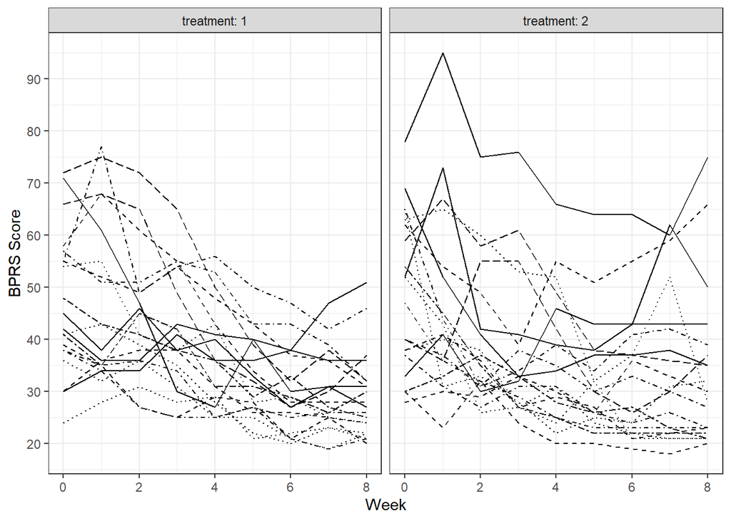

```r
ggplot(long_BPRS, aes(x = week, y = bprs_score, linetype = subject)) +
  geom_line() +
  scale_linetype_manual(values = rep(1:10, times=4)) +
  facet_grid(. ~ treatment, labeller = label_both) +
  theme(legend.position = "none") +
  scale_y_continuous(name = "BPRS Score", limits = c(min(long_BPRS$bprs_score), max(long_BPRS$bprs_score)), seq(0,100,10)) + labs(x = "Week") + theme_bw() + theme(legend.position = "none")
```

From this we see a general trend for the BPRS score to decrease over time, though the actual measurements display some rather wild individual variation and exceptions. We also see that the two treatment groups arrive at similar scores on week 8, roughly between 20 and 35, and any statistically significant differences between scores and the two treatment groups is extremely difficult to spot.

## 3.3 Multiple Linear Regression

A multiple linear regression model reveals that time is strongly related to bprs score but the treatment groups (compared to each other) are not.

```r
lm_BPRS <- lm(bprs_score ~ week + treatment, data = long_BPRS)
summary(lm_BPRS)
```

```
##
## Call:
## lm(formula = bprs_score ~ week + treatment, data = long_BPRS)
##
## Residuals:
##     Min      1Q  Median      3Q     Max
## -22.454  -8.965  -3.196   7.002  50.244
##
## Coefficients:
##             Estimate Std. Error t value Pr(>|t|)
## (Intercept)  46.4539     1.3670  33.982   <2e-16 ***
## week         -2.2704     0.2524  -8.995   <2e-16 ***
## treatment2    0.5722     1.3034   0.439    0.661
## ---
## Signif. codes:  0 '***' 0.001 '**' 0.01 '*' 0.05 '.' 0.1 ' ' 1
##
## Residual standard error: 12.37 on 357 degrees of freedom
## Multiple R-squared:  0.1851, Adjusted R-squared:  0.1806
## F-statistic: 40.55 on 2 and 357 DF,  p-value: < 2.2e-16
```

But here time is only strongly related because it is a dependent variable, as the measures are repeated on the same subject over time.

## 3.4 Linear Mixed Effects Models

### 3.4.1 Random Intercept Model

Random intercept model can be used to eschew the effects of a dependent variable. For the random intercept model we want to fit the test subjects as the random effect. Now, because we have the subject as a 20 level factor (with subject 1:20 for both treatment groups) I *suspect* we want to create a new identifier for each individual subject, so I create a new column for test subjects with a unique factor level for each. I do this by temporarily changing the subject class to numeric and then `mutate()` a new variable where the subject number is added by 20 for those subject numbers in treatment 2 group. Then I change both the variables to factors, so the new_subject category now is classed as factor with 40 levels.

```r
library(lme4)
long_BPRS$subject <- as.numeric(long_BPRS$subject)
long_BPRS <- long_BPRS %>% mutate(new_subject = case_when(treatment == "1" ~ subject,
                                                          treatment == "2" ~ subject + 20))
long_BPRS$subject <- as.factor(long_BPRS$subject)
long_BPRS$new_subject <- as.factor(long_BPRS$new_subject)
str(long_BPRS)
```

```
## 'data.frame':    360 obs. of  6 variables:
##  $ treatment  : Factor w/ 2 levels "1","2": 1 1 1 1 1 1 1 1 1 1 ...
##  $ subject    : Factor w/ 20 levels "1","2","3","4",..: 1 2 3 4 5 6 7 8 9 10 ...
##  $ weeks      : chr  "week0" "week0" "week0" "week0" ...
##  $ bprs_score : int  42 58 54 55 72 48 71 30 41 57 ...
##  $ week       : int  0 0 0 0 0 0 0 0 0 0 ...
##  $ new_subject: Factor w/ 40 levels "1","2","3","4",..: 1 2 3 4 5 6 7 8 9 10 ...
```

A random intercept model is created with the `lmer()` function from `lme4` package. The formula is specified similarly to `lm()`.

```r
BPRS_ref <- lmer(bprs_score ~ week + treatment + (1 | new_subject), data = long_BPRS, REML = FALSE)


summary(BPRS_ref)
```

```
## Linear mixed model fit by maximum likelihood  ['lmerMod']
## Formula: bprs_score ~ week + treatment + (1 | new_subject)
##    Data: long_BPRS
##
##      AIC      BIC   logLik deviance df.resid
##   2582.9   2602.3  -1286.5   2572.9      355
##
## Scaled residuals:
##      Min       1Q   Median       3Q      Max
## -2.27506 -0.59909 -0.06104  0.44226  3.15835
##
## Random effects:
##  Groups      Name        Variance Std.Dev.
##  new_subject (Intercept) 97.39    9.869
##  Residual                54.23    7.364
## Number of obs: 360, groups:  new_subject, 40
##
## Fixed effects:
##             Estimate Std. Error t value
## (Intercept)  46.4539     2.3521  19.750
## week         -2.2704     0.1503 -15.104
## treatment2    0.5722     3.2159   0.178
##
## Correlation of Fixed Effects:
##            (Intr) week
## week       -0.256
## treatment2 -0.684  0.000
```

### 3.4.2 Random Intercept and Slope

The random intercept model can be tested with additional random slope by defining the weeks as another random effect `(week | new_subject)`. This model accounts for linear regression fits for each individual to differ in intercept but also in slope, allowing for individual differences in subjects to be accounted for in the model. A summary of this model shows a Fixed Effects t-value of -8.37 for week and 0.48 for treatment 2 group (with group 1 as the reference group). This still means that the groups are fairly similar in their development over time.

```r
BPRS_ref1 <- lmer(bprs_score ~ week + treatment + (week | new_subject), data = long_BPRS, REML = FALSE)
summary(BPRS_ref1)
```

```
## Linear mixed model fit by maximum likelihood  ['lmerMod']
## Formula: bprs_score ~ week + treatment + (week | new_subject)
##    Data: long_BPRS
##
##      AIC      BIC   logLik deviance df.resid
##   2523.2   2550.4  -1254.6   2509.2      353
##
## Scaled residuals:
##     Min      1Q  Median      3Q     Max
## -2.4655 -0.5150 -0.0920  0.4347  3.7353
##
## Random effects:
##  Groups      Name        Variance Std.Dev. Corr
##  new_subject (Intercept) 167.827  12.955
##              week          2.331   1.527   -0.67
##  Residual                 36.747   6.062
## Number of obs: 360, groups:  new_subject, 40
##
## Fixed effects:
##             Estimate Std. Error t value
## (Intercept)  45.9830     2.6470  17.372
## week         -2.2704     0.2713  -8.370
## treatment2    1.5139     3.1392   0.482
##
## Correlation of Fixed Effects:
##            (Intr) week
## week       -0.545
## treatment2 -0.593  0.000
```

An anova test, below, shows the likelihood ratio test for the random intercept model versus the random intercept and slope model gives a chi-squared statistic of 63.7 with 2 dimensions of freedom. The associated p-value is very small < 0.001 indicating that the random intercept and slope model provides a better fit for the data than the random intercept model.

```r
anova(BPRS_ref, BPRS_ref1)
```

```
## Data: long_BPRS
## Models:
## BPRS_ref: bprs_score ~ week + treatment + (1 | new_subject)
## BPRS_ref1: bprs_score ~ week + treatment + (week | new_subject)
##           npar    AIC    BIC  logLik deviance  Chisq Df Pr(>Chisq)
## BPRS_ref     5 2582.9 2602.3 -1286.5   2572.9
## BPRS_ref1    7 2523.2 2550.4 -1254.6   2509.2 63.663  2  1.499e-14 ***
## ---
## Signif. codes:  0 '***' 0.001 '**' 0.01 '*' 0.05 '.' 0.1 ' ' 1
```

### 3.4.3 Model with Random Intercept and Slope allowing for Interaction

The model can be further tested with interaction of the measure week and treatment group. Interaction is formulated by changing the formula to `bprs_score ~ week * treatment + (week | subject)`.

```r
BPRS_ref2 <- lmer(bprs_score ~ week * treatment + (week | new_subject), data = long_BPRS, REML = FALSE)

summary(BPRS_ref2)
```

```
## Linear mixed model fit by maximum likelihood  ['lmerMod']
## Formula: bprs_score ~ week * treatment + (week | new_subject)
##    Data: long_BPRS
##
##      AIC      BIC   logLik deviance df.resid
##   2523.5   2554.5  -1253.7   2507.5      352
##
## Scaled residuals:
##     Min      1Q  Median      3Q     Max
## -2.4747 -0.5256 -0.0866  0.4435  3.7884
##
## Random effects:
##  Groups      Name        Variance Std.Dev. Corr
##  new_subject (Intercept) 164.204  12.814
##              week          2.203   1.484   -0.66
##  Residual                 36.748   6.062
## Number of obs: 360, groups:  new_subject, 40
##
## Fixed effects:
##                 Estimate Std. Error t value
## (Intercept)      47.8856     2.9840  16.047
## week             -2.6283     0.3752  -7.006
## treatment2       -2.2911     4.2200  -0.543
## week:treatment2   0.7158     0.5306   1.349
##
## Correlation of Fixed Effects:
##             (Intr) week   trtmn2
## week        -0.668
## treatment2  -0.707  0.473
## wek:trtmnt2  0.473 -0.707 -0.668
```

An analysis of variance, below, reveals the likelihood ratio test of the interaction random intercept and slope model against the corresponding model without an interaction is 1.78 with 1 dimension of freedom. An associated p-value is 0.18, which is *smallish* but doesn’t imply significance. We might interpret that this model with interaction is, in fact, not a better fit to the data than the previous model of random intercept and random slope, although the difference between them is small (the AIC, for example, increases by just 0.3).

```r
anova(BPRS_ref2,BPRS_ref1)
```

```
## Data: long_BPRS
## Models:
## BPRS_ref1: bprs_score ~ week + treatment + (week | new_subject)
## BPRS_ref2: bprs_score ~ week * treatment + (week | new_subject)
##           npar    AIC    BIC  logLik deviance Chisq Df Pr(>Chisq)
## BPRS_ref1    7 2523.2 2550.4 -1254.6   2509.2
## BPRS_ref2    8 2523.5 2554.6 -1253.7   2507.5  1.78  1     0.1821
```

### 3.4.4 Plotting Fitted Results

The model with the best fit was the random intercept and slope model. This model can be used to get fitted regression coefficients. These can be plotted and compared to the actual observations:

```r
Fitted <- fitted(BPRS_ref1)
long_BPRS <- long_BPRS %>% mutate(Fitted)
```

These fitted values can be plotted and compared to the actual observations:

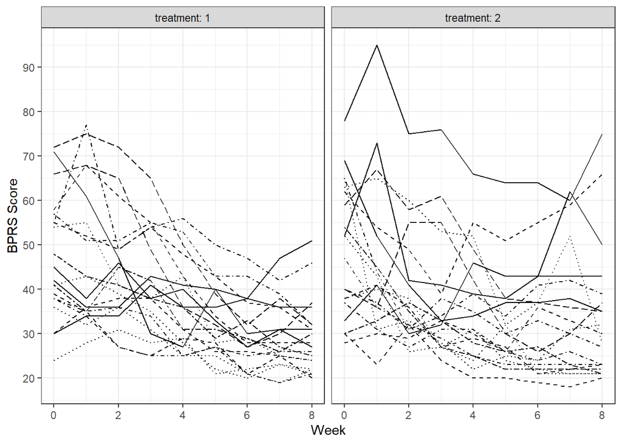

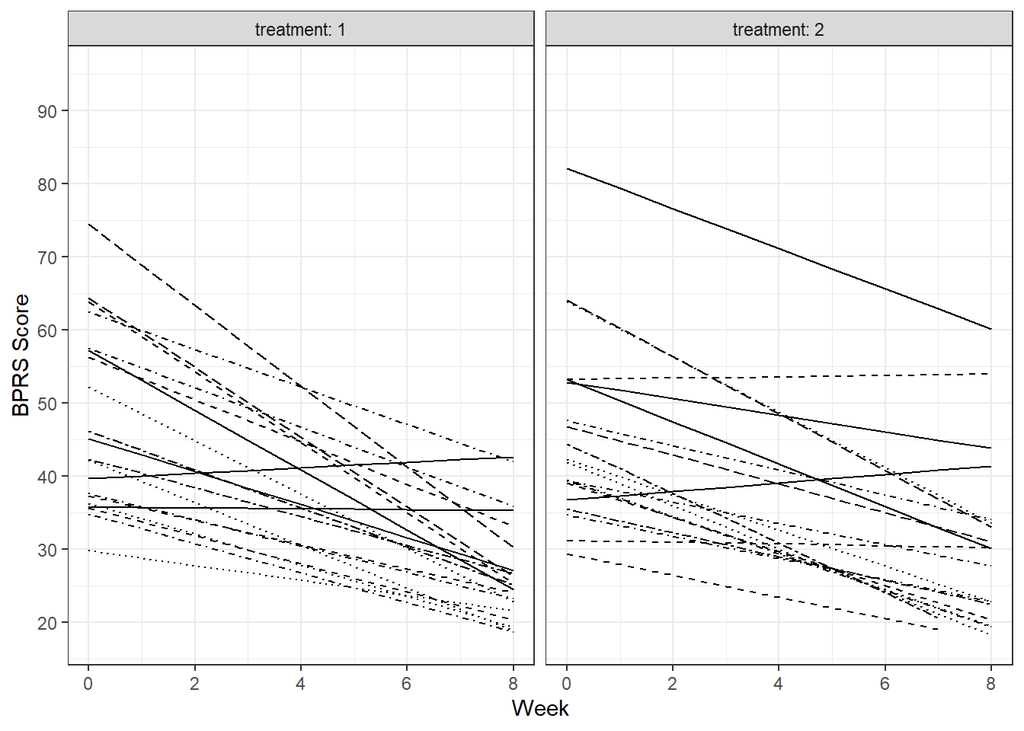

```r
p_BPRS <- ggplot(long_BPRS, aes(x = week, y = bprs_score, linetype = new_subject)) +
  geom_line() +
  scale_linetype_manual(values = rep(1:10, times=4)) +
  facet_grid(. ~ treatment, labeller = label_both) +
  theme(legend.position = "none") +
  scale_y_continuous(name = "BPRS Score", limits = c(min(long_BPRS$bprs_score), max(long_BPRS$bprs_score)), seq(0,100,10)) + labs(x = "Week") + theme_bw() + theme(legend.position = "none")

p_Fitted <- ggplot(long_BPRS, aes(x = week, y = Fitted, linetype = new_subject)) +
  geom_line() +
  scale_linetype_manual(values = rep(1:10, times=4)) +
  facet_grid(. ~ treatment, labeller = label_both) +
  theme(legend.position = "none") +
  scale_y_continuous(name = "BPRS Score", limits = c(min(long_BPRS$bprs_score), max(long_BPRS$bprs_score)), seq(0,100,10)) + labs(x = "Week") + theme_bw() + theme(legend.position = "none")

p_BPRS;p_Fitted
```